# Empirical Study for Master Thesis

Nhu Le

2021-12-31

# Empirical Study for Master Thesis

## Required packages

```r
# install.packages(c(
#     "tidyverse",
#     "MSGARCH",
#     "e1071",
#     "patchwork",
#     "tseries",
#     "bridgesampling",
#     "GAS"
# ))
```

## Imports

```r
library(tidyverse)
```

```r
library(MSGARCH)
library(e1071)
library(ggplot2)
library(patchwork)
library(tseries)
library(bridgesampling)
library(GAS)
library(parallel)

Sys.setenv(LANGUAGE="en")
Sys.setlocale("LC_TIME", "English")
```

```
## [1] ""
```

## Read and Process data

```r
bf_data_path <- "raw_data/bitfinex_btc_usd_20150101_20211220.csv"
yh_data_path <- "raw_data/yahoo_btc_usd_20150101_20211220.csv"
bf_data <- read_csv(bf_data_path)
yh_data <- read_csv(yh_data_path)
# process bf
bf_data$Date = parse_date(bf_data$Date, "%b %d, %Y")
bf_data <- bf_data %>%
    arrange(Date) %>% # parse datetime and sort
    mutate(return=(.$Price - lag(.$Price)) /  lag(.$Price)) %>% # calculate return
    mutate(log_return=log(1 + .$return) * 100) %>% # log return
    drop_na(return)
# process yh
yh_data <- yh_data %>%
    arrange(Date) %>%
    mutate(return=(.$Close - lag(.$Close)) /  lag(.$Close)) %>%
    mutate(log_return=log(1 + .$return) * 100) %>%
    drop_na(return)

# inspect
bf_data[1:5, ]
```

```
## # A tibble: 5 × 9
##   Date       Price  Open  High   Low Vol.  `Change %`   return log_return
##   <date>     <dbl> <dbl> <dbl> <dbl> <chr> <chr>         <dbl>      <dbl>
## 1 2015-01-02  315.  314.  316   313  1.32K 0.40%       0.00382      0.382
## 2 2015-01-03  282   315.  315.  282  1.30K -10.51%    -0.105      -11.1
## 3 2015-01-04  259.  282   289.  259. 2.38K -8.23%     -0.0823      -8.59
## 4 2015-01-05  273.  261   276.  260. 2.68K 5.57%       0.0556       5.41
## 5 2015-01-06  285.  273.  288.  268. 6.86K 4.46%       0.0447       4.37
```

```r
yh_data[1:5, ]
```

```
## # A tibble: 5 × 9
##   Date        Open  High   Low Close `Adj Close`     Volume  return log_return
##   <date>     <dbl> <dbl> <dbl> <dbl>       <dbl>      <dbl>   <dbl>      <dbl>
## 1 2017-11-10 7174. 7312  6437. 6618.       6618. 5208249856 -0.0736      -7.64
## 2 2017-11-11 6619. 6873. 6204. 6358.       6358. 4908680192 -0.0394      -4.02
## 3 2017-11-12 6295. 6625. 5519. 5950.       5950. 8957349888 -0.0641      -6.62
## 4 2017-11-13 5938. 6811. 5844. 6559.       6559. 6263249920  0.102        9.75
## 5 2017-11-14 6561. 6765. 6462. 6636.       6636. 3197110016  0.0116       1.16
```

## Dataset comparison

Here we compare the 2 datasets

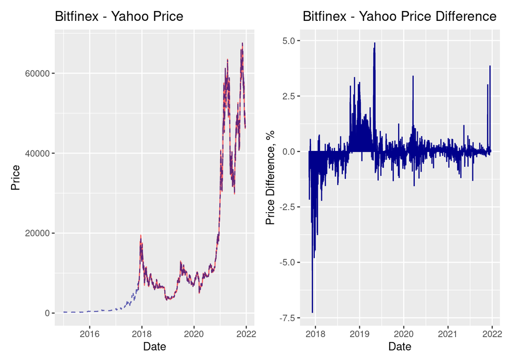

```r
diff_data <- bf_data %>%
    filter(Date >= min(yh_data$Date)) %>%
    mutate(
        diff_price=(Price - yh_data$Close) / yh_data$Close * 100,
        diff_return=(log_return - yh_data$log_return) / yh_data$log_return
    )

price_plot <- ggplot() +
    geom_line(
        data=yh_data,
        aes(x=Date, y=Close),
        color="red",
        alpha=0.6) +
    geom_line(
        data=bf_data,
        aes(x=Date, y=Price),
        color="darkblue",
        linetype="dashed",
        alpha=0.6) +
    # scale_y_continuous(
    #     trans='log10',
    #     name="BTC-USD Price"
    # ) +
    xlab("Date") +
    ylab("Price") +
    ggtitle('Bitfinex - Yahoo Price')

price_diff_plot <- ggplot() +
    geom_col(
        data=diff_data,
        aes(x=Date, y=diff_price),
        color="darkblue",
        alpha = 0.5
        ) +
    # scale_y_continuous(
    #     trans='log10'
    # ) +
    xlab("Date") +
    ylab("Price Difference, %") +
    theme(plot.title = element_text(hjust = 0.5)) +
    ggtitle('Bitfinex - Yahoo Price Difference')

price_plot + price_diff_plot
```

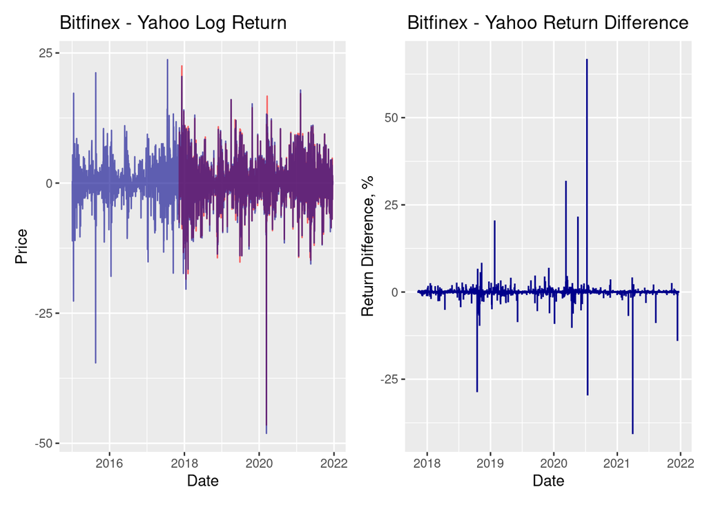

```r
return_plot <- ggplot() +
    geom_line(
        data=yh_data,
        aes(x=Date, y=log_return),
        color="red",
        alpha=0.6) +
    geom_line(
        data=bf_data,
        aes(x=Date, y=log_return),
        color="darkblue",
        alpha=0.6) +
    # scale_y_continuous(
    #     trans='log',
    #     name="BTC-USD Return"
    # ) +
    xlab("Date") +
    ylab("Price") +
    ggtitle('Bitfinex - Yahoo Log Return')

return_diff_plot <- ggplot() +
    geom_col(
        data=diff_data,
        aes(x=Date, y=diff_return),
        # stat='identity',
        color="darkblue",
        alpha = 0.5
        ) +
    # scale_y_continuous(
    #     trans='log'
    # ) +
    xlab("Date") +
    ylab("Return Difference, %") +
    theme(plot.title = element_text(hjust = 0.5)) +
    ggtitle('Bitfinex - Yahoo Return Difference')

return_plot + return_diff_plot
```

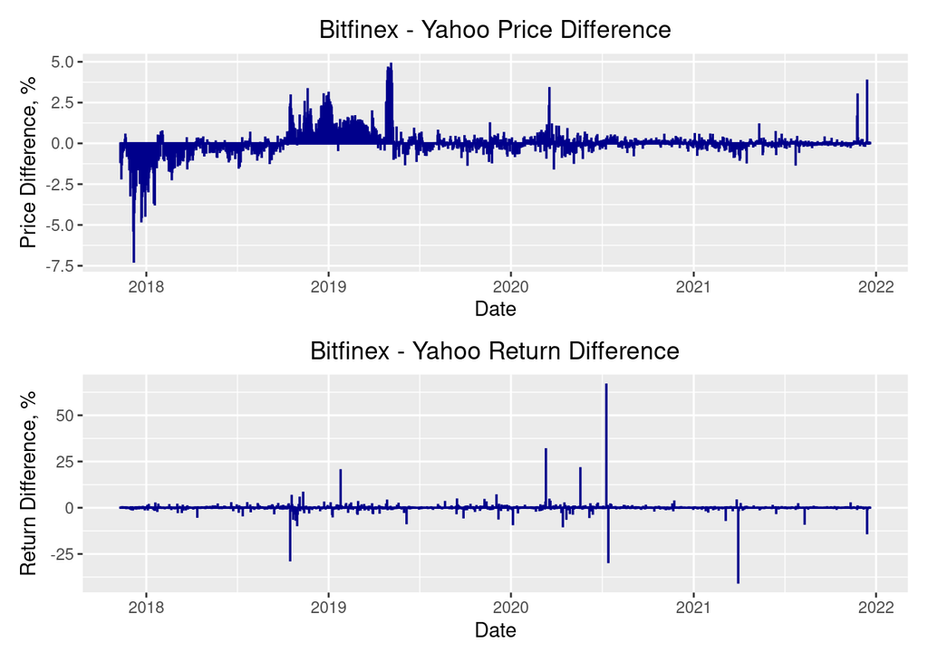

```r
data_diff_plot <- price_diff_plot / return_diff_plot
ggsave(
    "./latex/empirical_results/data_diff.png",
    data_diff_plot,
    width = 8,
    height = 5,
    dpi = "print"
)
data_diff_plot
```

## Descriptive Analysis

Descriptive analysis using Bitfinex data includes: - Max, Min, Mean, Median, Std - Skewness, Kurtosis, Jb p-value - Histogram

### Summary

```r
summary_stats <- as_tibble(data.frame(
    Min=min(bf_data$log_return),
    Max=max(bf_data$log_return),
    Mean=mean(bf_data$log_return),
    Median=median(bf_data$log_return),
    Std=sd(bf_data$log_return),
    Annualized_std=sqrt(365) * sd(bf_data$log_return),
    Skewness=skewness(bf_data$log_return),
    Kurtosis=kurtosis(bf_data$log_return),
    JB_pval=jarque.bera.test(bf_data$log_return)$p.value
))

knitr::kable(summary_stats, "simple")
```

| Min | Max | Mean | Median | Std | Annualized_std | Skewness | Kurtosis | JB_pval |
| --- | --- | --- | --- | --- | --- | --- | --- | --- |
| -48.0904 | 23.722 | 0.1968799 | 0.1762593 | 4.077418 | 77.89896 | -0.9655894 | 12.792 | 0 |

### Plots

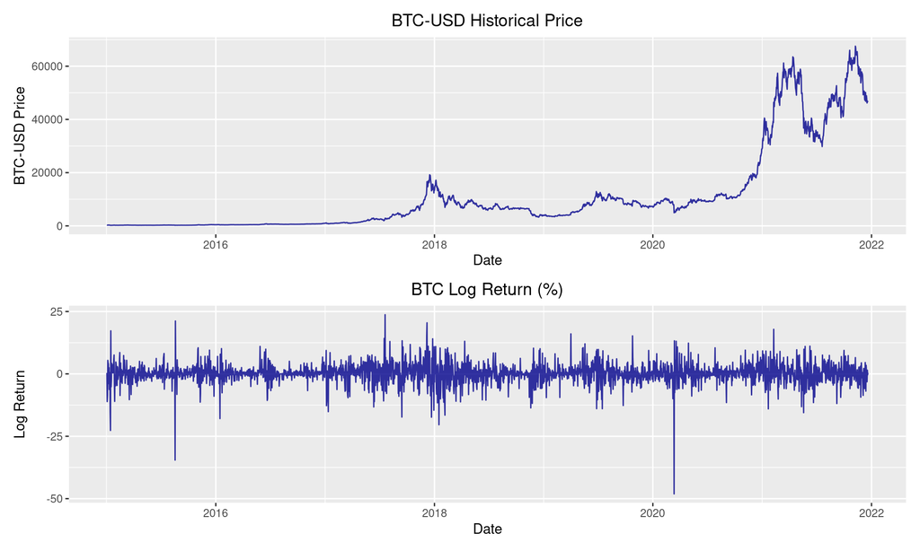

```r
# plot prices and returns
price_plot <- ggplot() +
    geom_line(
        data=bf_data,
        aes(x=Date, y=Price),
        color="darkblue",
        alpha=0.8) +
    xlab("Date") +
    ylab("BTC-USD Price") +
    theme(plot.title = element_text(hjust = 0.5)) +
    ggtitle("BTC-USD Historical Price")

return_plot <- ggplot() +
    geom_line(
        data=bf_data,
        aes(x=Date, y=log_return),
        color="darkblue",
        alpha=0.8) +
    xlab("Date") +
    ylab("Log Return") +
    theme(plot.title = element_text(hjust = 0.5)) +
    ggtitle('BTC Log Return (%)')
price_return_plot <- price_plot / return_plot
ggsave(
    "./latex/empirical_results/price_return.png",
    price_return_plot,
    width = 8,
    height = 5,
    dpi = "print"
)
price_return_plot
```

### Histograms

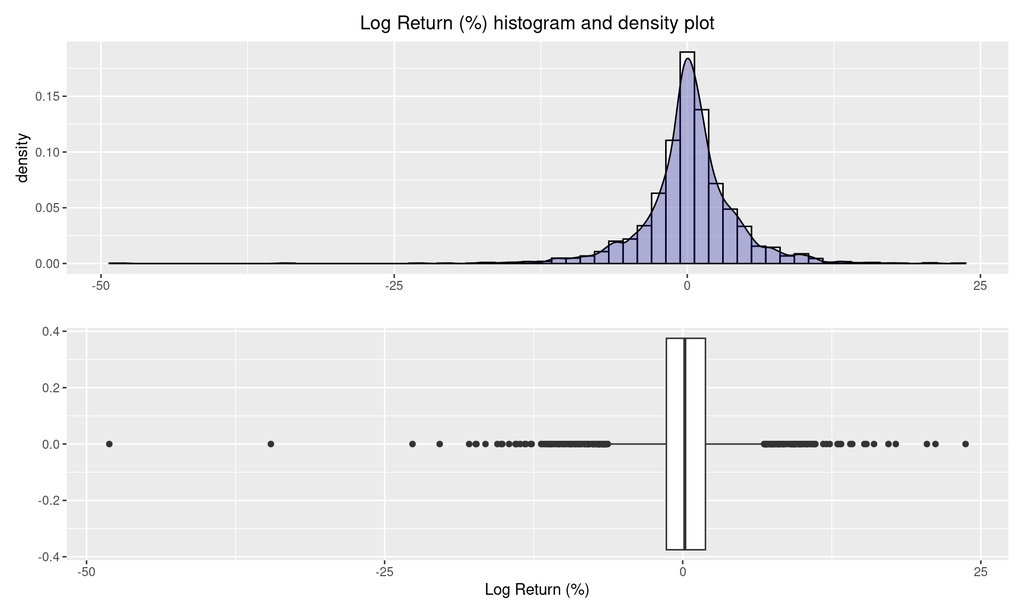

```r
# plot histogram
hist_plot <- ggplot(data=bf_data, aes(log_return)) +
    geom_histogram(
        aes(y=..density..),
        bins=60,
        colour="black",
        fill="white",
        alpha=0.5
    ) +
    geom_density(fill='darkblue', alpha=.3) +
    xlab("") +
    theme(plot.title = element_text(hjust = 0.5)) +
    ggtitle("Log Return (%) histogram and density plot")

box_plot <- ggplot(data=bf_data, aes(log_return)) +
    xlab("Log Return (%)") +
    geom_boxplot()

hist_box_plot <- hist_plot / box_plot

ggsave(
    "./latex/empirical_results/density.png",
    hist_box_plot,
    width = 8,
    height = 5,
    dpi = "print"
)
hist_box_plot
```

### Lags analysis

Next, we do some initial time series analysis with ACF and PACF. As in the ACF plot for log return, there is no strong evidence that indicates autocorrelation. However, absolute returns show long diminishing autocorrelation, indicating possible variance clustering, where large changes happen close to each other.

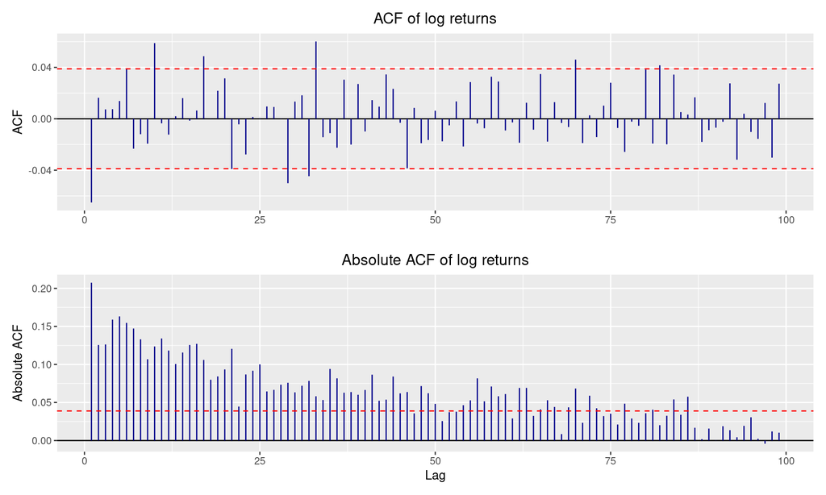

```r
max_lags = 100
acf_data <- with(
    acf(bf_data$log_return, lag.max=max_lags, plot=FALSE),
    as_tibble(data.frame(lag, acf))
)
abs_acf_data <- with(
    acf(abs(bf_data$log_return), lag.max=max_lags, plot=FALSE),
    as_tibble(data.frame(lag, acf))
)
pacf_data <- with(
    pacf(bf_data$log_return, lag.max=max_lags, plot=FALSE),
    as_tibble(data.frame(lag, acf))
)
bounds <- c(- 1.96 / sqrt(nrow(bf_data)), 1.96 / sqrt(nrow(bf_data)))

acf_plot <- ggplot(data=acf_data[2:max_lags, ], aes(x=lag, y=acf)) +
    geom_hline(aes(yintercept=0)) +
    geom_segment(mapping=aes(xend=lag, yend=0), color="darkblue") +
    geom_hline(aes(yintercept=bounds[1]), color="red", linetype="dashed") +
    geom_hline(aes(yintercept=bounds[2]), color="red", linetype="dashed") +
    xlab("") +
    ylab("ACF") +
    theme(plot.title = element_text(hjust = 0.5)) +
    ggtitle("ACF of log returns")

abs_acf_plot <- ggplot(data=abs_acf_data[2:max_lags, ], aes(x=lag, y=acf)) +
    geom_hline(aes(yintercept=0)) +
    geom_segment(mapping=aes(xend=lag, yend=0), color="darkblue") +
    geom_hline(aes(yintercept=bounds[2]), color="red", linetype="dashed") +
    xlab("Lag") +
    ylab("Absolute ACF") +
    theme(plot.title = element_text(hjust = 0.5)) +
    ggtitle("Absolute ACF of log returns")

lag_plot <- acf_plot / abs_acf_plot
ggsave(
    "./latex/empirical_results/acf.png",
    lag_plot,
    width = 8,
    height = 5,
    dpi = "print"
)
lag_plot
```

## In-sample analysis

Demean and filter data first

```r
filter_return <- function(log_return) {
    demeaned_log_return <- log_return - mean(log_return)
    as.vector(stats::filter(
        demeaned_log_return,
        ar(demeaned_log_return, demean = FALSE)$ar,
        method = c("recursive")
    ))
}
bf_data <- bf_data %>%
    mutate(f_log_return = filter_return(bf_data$log_return))
```

First we perform model selection between some settings. - Model specifications: sGARCH and GJR - Number of regimes: 1, 2, 3 - Distributions: Standard Normal, Student-t, Skewed Student-t

Selection criteria will AIC, BIC, DIC

### Parameters estimation

```r
# first set seed to ensure reproducibility
set.seed(267)

# create model specifications
# options
model_choices = c("sGARCH", "gjrGARCH")
regime_choices = c(1, 2, 3)
dist_choices = c("norm", "std", "sstd")
# optim_method_names = c("FitML")
optim_method_names = c("FitMCMC", "FitML")
model_options = expand_grid(
    model_choices, dist_choices, regime_choices, optim_method_names)

# set up routine function
i = 1

fit_model <- function(specs, data) {
    start_time <- proc.time()
    # make option
    these_options <- list(
        model=c(specs[["model_choices"]]),
        distribution=c(specs[["dist_choices"]]),
        do.mix=FALSE,
        K=specs[["regime_choices"]]
    )
    optim_func <- get(specs[["optim_method_names"]])
    # create model specs
    model_specs <- CreateSpec(
        variance.spec=these_options,
        distribution.spec=these_options,
        switch.spec=these_options
    )
    optim_result <- optim_func(spec=model_specs, data=data)
    elapsed_time <- proc.time() - start_time
    info_str <- sprintf(
        "--- Specs %i/%i, optimizer %s, took %f",
        i,
        nrow(model_options),
        specs[["optim_method_names"]],
        elapsed_time[["elapsed"]])
    print(info_str)
    # print(model_specs)
    i <<- i + 1
    optim_result$elapsed_time <- elapsed_time[["elapsed"]]
    # return the result
    optim_result
}

optim_results = apply(
    X = model_options,
    MARGIN = 1,
    FUN = function(x) fit_model(x, data = bf_data$log_return)
)
```

```
## [1] "--- Specs 1/36, optimizer FitMCMC, took 2.066000"
## [1] "--- Specs 2/36, optimizer FitML, took 0.053000"
## [1] "--- Specs 3/36, optimizer FitMCMC, took 14.533000"
## [1] "--- Specs 4/36, optimizer FitML, took 1.397000"
## [1] "--- Specs 5/36, optimizer FitMCMC, took 14.252000"
## [1] "--- Specs 6/36, optimizer FitML, took 5.706000"
## [1] "--- Specs 7/36, optimizer FitMCMC, took 2.259000"
## [1] "--- Specs 8/36, optimizer FitML, took 0.082000"
## [1] "--- Specs 9/36, optimizer FitMCMC, took 14.511000"
## [1] "--- Specs 10/36, optimizer FitML, took 2.660000"
## [1] "--- Specs 11/36, optimizer FitMCMC, took 14.354000"
## [1] "--- Specs 12/36, optimizer FitML, took 6.995000"
## [1] "--- Specs 13/36, optimizer FitMCMC, took 2.570000"
## [1] "--- Specs 14/36, optimizer FitML, took 0.123000"
## [1] "--- Specs 15/36, optimizer FitMCMC, took 13.944000"
```

[output cut: 21 more lines]

### ML Estimation analysis

Take a look at FitML results first

```r
ml_model_options <- model_options %>%
    filter(optim_method_names == "FitML")

ml_optim_results <- optim_results[model_options$optim_method_names == "FitML"]

ml_model_options$AIC_val = sapply(ml_optim_results, function(x) {AIC(x)})
ml_model_options$BIC_val = sapply(ml_optim_results, function(x) {BIC(x)})

ml_model_options <- ml_model_options %>%
    pivot_wider(
        id_cols=c(regime_choices, model_choices),
        names_from=c(dist_choices),
        values_from=c(AIC_val, BIC_val)
    ) %>%
    arrange(regime_choices, desc(model_choices)) %>%
    relocate(
        regime_choices, model_choices,
        AIC_val_norm, BIC_val_norm,
        AIC_val_std, BIC_val_std,
        AIC_val_sstd, BIC_val_sstd
    )

knitr::kable(ml_model_options, "simple")
```

| regime_choices | model_choices | AIC_val_norm | BIC_val_norm | AIC_val_std | BIC_val_std | AIC_val_sstd | BIC_val_sstd |
| --- | --- | --- | --- | --- | --- | --- | --- |
| 1 | sGARCH | 14004.34 | 14021.87 | 13245.00 | 13268.37 | 13240.53 | 13269.73 |
| 1 | gjrGARCH | 13988.52 | 14011.89 | 13247.04 | 13276.25 | 13242.55 | 13277.60 |
| 2 | sGARCH | 13302.14 | 13348.87 | 13170.72 | 13229.13 | 13164.10 | 13234.19 |
| 2 | gjrGARCH | 13455.47 | 13513.88 | 13199.81 | 13269.91 | 13329.56 | 13411.33 |
| 3 | sGARCH | 13236.79 | 13324.41 | 13174.75 | 13279.89 | 13168.59 | 13291.25 |
| 3 | gjrGARCH | 13352.58 | 13457.72 | 13189.45 | 13312.11 | 13174.83 | 13315.01 |

```r
# get models for further analysis
chosen_models_mask <- {
    (model_options$dist_choices == "sstd") &
    (model_options$model_choices == "sGARCH") &
    (model_options$optim_method_names == "FitML")
}
chosen_models = optim_results[chosen_models_mask]

# calculate annualized volatility
calculate_annualized_volatility <- function(full_model) {
    # first expand the regimes
    regimes = ExtractStateFit(full_model)
    uncond_vols = lapply(regimes, UncVol)
    lapply(uncond_vols, function(x) {sqrt(365) * x})
}


arrange_params_estimates <- function(ml_model) {
    # prepare some vars
    num_regimes <- ml_model$spec$K
    param_names <- names(ml_model$par)
    regimes <- str_split(param_names, "_", simplify = TRUE)[, 2]
    unique_regimes <- unique(regimes)

    # calculate annualized vols
    ann_vol <- unlist(calculate_annualized_volatility(ml_model))
    ann_vol_param_names <- sapply(
        unique_regimes,
        function(x) paste("ann_vol", x, sep = "_")
    )
    ann_vol_df <- tibble(
        param = ann_vol_param_names,
        regime = unique_regimes,
        est = ann_vol
    ) %>%
    rename_with(function(x) {paste("est", num_regimes, sep = "_")}, "est")


    # organize into tibble
    summary_df <- as_tibble(summary(ml_model)$estimate)
    colnames(summary_df) <- sapply(
        c("est", "stderr", "tstat", "pval"),
        function(x) paste(x, num_regimes, sep = "_")
    )
    summary_df %>%
        mutate(
            param = param_names,
            regime = regimes,
            .before = paste("est", num_regimes, sep = "_")
        ) %>%
        bind_rows(., ann_vol_df) %>%
        arrange(regime, param)
}

ml_params <- lapply(
    chosen_models,
    arrange_params_estimates
)
```

```
## Specification type: Single-regime
## Specification name: sGARCH_sstd
## Number of parameters in variance model: 3
## Number of parameters in distribution: 2
## ------------------------------------------
## Fitted parameters:
##          Estimate Std. Error   t value Pr(>|t|)
## alpha0_1   0.1967     0.0627    3.1385 8.49e-04
## alpha1_1   0.1115     0.0731    1.5260 6.35e-02
## beta_1     0.8873     0.0008 1164.8750   <1e-16
## nu_1       3.3585     0.1494   22.4773   <1e-16
## xi_1       0.9513     0.0187   50.9096   <1e-16
## ------------------------------------------
## LL: -6615.2625
## AIC: 13240.525
## BIC: 13269.7305
## ------------------------------------------
## Specification type: Markov-switching
## Specification name: sGARCH_sstd sGARCH_sstd
## Number of parameters in each variance model: 3 3
## Number of parameters in each distribution: 2 2
## ------------------------------------------
## Fixed parameters:
## None
## ------------------------------------------
## Across regime constrained parameters:
## None
## ------------------------------------------
## Fitted parameters:
##          Estimate Std. Error   t value  Pr(>|t|)
## alpha0_1   0.9424     0.3635    2.5924 4.766e-03
## alpha1_1   0.0721     0.0413    1.7471 4.031e-02
## beta_1     0.8924     0.0178   50.0247    <1e-16
## nu_1       5.2787     1.0495    5.0296 2.458e-07
## xi_1       0.9149     0.0324   28.2106    <1e-16
## alpha0_2   0.2971     0.1467    2.0247 2.145e-02
## alpha1_2   0.0781     0.0610    1.2812 1.001e-01
## beta_2     0.9213     0.0004 2268.1716    <1e-16
## nu_2       2.3258     0.0814   28.5759    <1e-16
## xi_2       0.9540     0.0270   35.2731    <1e-16
```

[output cut: 50 more lines]

```
## ------------------------------------------
## Transition matrix:
##       t+1|k=1 t+1|k=2 t+1|k=3
## t|k=1  0.9762  0.0092  0.0146
## t|k=2  0.0274  0.9720  0.0006
## t|k=3  0.0197  0.0000  0.9803
## ------------------------------------------
## Stable probabilities:
## State 1 State 2 State 3
##  0.4811  0.1582  0.3608
## ------------------------------------------
## LL: -6563.2944
## AIC: 13168.5888
## BIC: 13291.2519
## ------------------------------------------
```

```r
ml_params_df <- as_tibble(
    Reduce(
        function(...) merge(..., by=c("param", "regime"), all = TRUE),
        ml_params
    )
) %>% arrange(regime, param)

knitr::kable(ml_params_df, "simple")
```

| param | regime | est_1 | stderr_1 | tstat_1 | pval_1 | est_2 | stderr_2 | tstat_2 | pval_2 | est_3 | stderr_3 | tstat_3 | pval_3 |
| --- | --- | --- | --- | --- | --- | --- | --- | --- | --- | --- | --- | --- | --- |
| alpha0_1 | 1 | 0.1967130 | 0.0626772 | 3.138510 | 0.0008490 | 0.9423743 | 0.3635201 | 2.592358 | 0.0047660 | 0.0000001 | 0 | 4.999998e+07 | 0 |
| alpha1_1 | 1 | 0.1115161 | 0.0730758 | 1.526033 | 0.0635008 | 0.0721064 | 0.0412709 | 1.747148 | 0.0403058 | 0.0144899 | 0 | 3.530829e+20 | 0 |
| ann_vol_1 | 1 | 89.2113696 | NA | NA | NA | 98.1903465 | NA | NA | NA | 0.6638722 | NA | NA | NA |
| beta_1 | 1 | 0.8873041 | 0.0007617 | 1164.874955 | 0.0000000 | 0.8924375 | 0.0178399 | 50.024731 | 0.0000000 | 0.9854099 | 0 | 4.287271e+31 | 0 |
| nu_1 | 1 | 3.3584751 | 0.1494164 | 22.477280 | 0.0000000 | 5.2787054 | 1.0495378 | 5.029553 | 0.0000002 | 2.8459372 | 0 | 4.543672e+20 | 0 |
| P_1_1 | 1 | NA | NA | NA | NA | 0.9877171 | 0.0055007 | 179.562003 | 0.0000000 | 0.9761960 | 0 | 1.973794e+23 | 0 |
| P_1_2 | 1 | NA | NA | NA | NA | NA | NA | NA | NA | 0.0092009 | 0 | 5.438991e+20 | 0 |
| xi_1 | 1 | 0.9512657 | 0.0186854 | 50.909581 | 0.0000000 | 0.9149356 | 0.0324323 | 28.210630 | 0.0000000 | 0.9344314 | 0 | 2.485680e+20 | 0 |
| alpha0_2 | 2 | NA | NA | NA | NA | 0.2971023 | 0.1467388 | 2.024703 | 0.0214490 | 0.0038380 | 0 | 2.604876e+21 | 0 |
| alpha1_2 | 2 | NA | NA | NA | NA | 0.0781066 | 0.0609634 | 1.281205 | 0.1000608 | 0.0097781 | 0 | 7.230289e+21 | 0 |
| ann_vol_2 | 2 | NA | NA | NA | NA | 59.2301640 | NA | NA | NA | 9.4739370 | NA | NA | NA |
| beta_2 | 2 | NA | NA | NA | NA | 0.9212543 | 0.0004062 | 2268.171564 | 0.0000000 | 0.9842259 | 0 | 2.544928e+23 | 0 |
| nu_2 | 2 | NA | NA | NA | NA | 2.3258370 | 0.0813916 | 28.575879 | 0.0000000 | 2.2125116 | 0 | 1.266422e+22 | 0 |
| P_2_1 | 2 | NA | NA | NA | NA | 0.0151516 | 0.0048311 | 3.136260 | 0.0008556 | 0.0274108 | 0 | 8.290850e+21 | 0 |
| P_2_2 | 2 | NA | NA | NA | NA | NA | NA | NA | NA | 0.9720181 | 0 | 6.874735e+31 | 0 |
| xi_2 | 2 | NA | NA | NA | NA | 0.9539555 | 0.0270448 | 35.273098 | 0.0000000 | 1.0018950 | 0 | 9.541961e+19 | 0 |
| alpha0_3 | 3 | NA | NA | NA | NA | NA | NA | NA | NA | 4.0207130 | 0 | 1.087256e+20 | 0 |
| alpha1_3 | 3 | NA | NA | NA | NA | NA | NA | NA | NA | 0.0957777 | 0 | 8.618255e+20 | 0 |
| ann_vol_3 | 3 | NA | NA | NA | NA | NA | NA | NA | NA | 110.1366953 | NA | NA | NA |
| beta_3 | 3 | NA | NA | NA | NA | NA | NA | NA | NA | 0.7830694 | 0 | 2.503946e+21 | 0 |
| nu_3 | 3 | NA | NA | NA | NA | NA | NA | NA | NA | 5.6672817 | 0 | 9.478941e+20 | 0 |
| P_3_1 | 3 | NA | NA | NA | NA | NA | NA | NA | NA | 0.0197229 | 0 | 1.150042e+21 | 0 |
| P_3_2 | 3 | NA | NA | NA | NA | NA | NA | NA | NA | 0.0000000 | 0 | 3.375483e+16 | 0 |
| xi_3 | 3 | NA | NA | NA | NA | NA | NA | NA | NA | 0.8617776 | 0 | 9.970673e+19 | 0 |

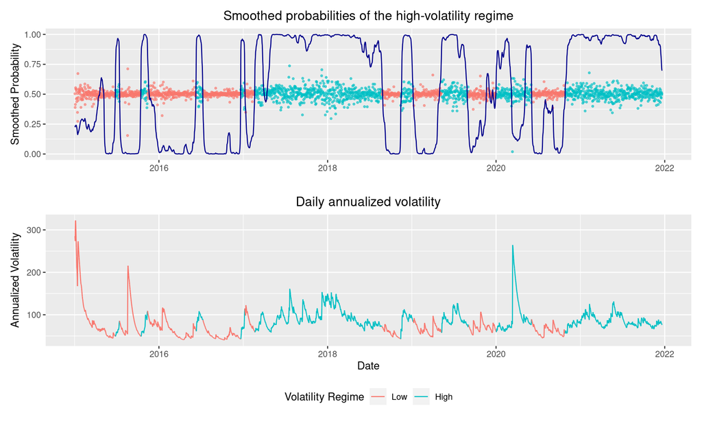

```r
getmode <- function(v) {
   uniqv <- unique(v)
   uniqv[which.max(tabulate(match(v, uniqv)))]
}

ml_ind <- 2
state <- State(object = chosen_models[[ml_ind]])
bf_data <- bf_data %>%
    mutate(
        smooth_prob_2 = state$SmoothProb[1:nrow(bf_data), 1, 1, drop = TRUE],
        volatility_2 = sqrt(365) * Volatility(chosen_models[[ml_ind]]),
        viterbi = as_factor(
            ifelse(apply(state$Viterbi, 1, getmode) == 1, "High", "Low")
        )
    )

smoothed_prob_plot = ggplot(data = bf_data, aes(x = Date)) +
    geom_point(
        aes(y = log_return / 100 + 0.5, color = viterbi),
        size = 0.7,
        alpha = 0.6
    ) +
    geom_line(aes(y = smooth_prob_2), color="darkblue") +
    xlab("") +
    ylab("Smoothed Probability") +
    theme(
        legend.position = "none",
        plot.title = element_text(hjust = 0.5)
    ) +
    ggtitle("Smoothed probabilities of the high-volatility regime")

volatility_plot = ggplot(data = bf_data, aes(x = Date)) +
    geom_line(aes(y = volatility_2, color = viterbi, group = 1)) +
    xlab("Date") +
    ylab("Annualized Volatility") +
    labs(color="Volatility Regime") +
    theme(
        legend.position = "bottom",
        plot.title = element_text(hjust = 0.5)
    ) +
    ggtitle("Daily annualized volatility")

prob_vol_plot <- smoothed_prob_plot / volatility_plot

ggsave(
    "./latex/empirical_results/prob_vol_plot.png",
    prob_vol_plot,
    width = 8,
    height = 5,
    dpi = "print"
)

prob_vol_plot
```

### Bayesian Estimation analysis

Calculate DIC for models fit by MCMC

```r
mcmc_model_options <- model_options %>%
    filter(optim_method_names == "FitMCMC")

mcmc_optim_results <- optim_results[
    model_options$optim_method_names == "FitMCMC"]

mcmc_model_options$DIC_val = sapply(mcmc_optim_results, function(x) {DIC(x)$DIC})

mcmc_model_options <- mcmc_model_options %>%
    pivot_wider(
        id_cols=c(regime_choices, model_choices),
        names_from=c(dist_choices),
        values_from=c(DIC_val)
    ) %>%
    arrange(regime_choices, desc(model_choices))

knitr::kable(mcmc_model_options, "simple")
```

| regime_choices | model_choices | norm | std | sstd |
| --- | --- | --- | --- | --- |
| 1 | sGARCH | 14004.80 | 13246.04 | 13241.44 |
| 1 | gjrGARCH | 13988.35 | 13250.38 | 13276.51 |
| 2 | sGARCH | 13304.08 | 13220.73 | 13205.15 |
| 2 | gjrGARCH | 13304.07 | 13209.85 | 13198.97 |
| 3 | sGARCH | 13339.55 | 13215.10 | 13297.04 |
| 3 | gjrGARCH | 13277.63 | 38241.28 | 13183.52 |

Get estimated parameters

```r
# get models for further analysis
mcmc_chosen_models_mask <- {
    (model_options$dist_choices == "sstd") &
    (model_options$model_choices == "gjrGARCH") &
    (model_options$optim_method_names == "FitMCMC")
}
mcmc_chosen_models = optim_results[mcmc_chosen_models_mask]

# calculate models [0.25, 0.75] quantiles
calculate_params_quantiles <- function(mcmc_model) {
    # prepare some vars
    probs <- c(0.25, 0.75)
    num_regimes <- mcmc_model$spec$K
    param_names <- colnames(mcmc_model$par)
    regimes <- str_split(param_names, "_", simplify = TRUE)[, 2]
    unique_regimes <- unique(regimes)
    # param_names <- sapply(
    #     colnames(mcmc_model$par),
    #     function(nm) {paste(num_regimes, nm, sep = "_")}
    # )
    # cal quantiles
    quant_results <- lapply(
        seq(1, ncol(mcmc_model$par)),
        function(x) {quantile(mcmc_model$par[, x], probs)}
    )
    # calculate annualized vols
    ann_vol <- unlist(calculate_annualized_volatility(mcmc_model))
    ann_vol_param_names <- sapply(
        unique_regimes,
        function(x) paste("ann_vol", x, sep = "_")
    )
    ann_vol_df <- tibble(
        param = ann_vol_param_names,
        regime = unique_regimes,
        val = ann_vol
    )
    # organize into tibble
    quant_df <- bind_rows(quant_results)
    colnames(quant_df) <- c(
        paste("first_quartile", num_regimes, sep = "_"),
        paste("second_quartile", num_regimes, sep = "_")
    )
    quant_df %>% mutate(
            param = param_names,
            regime = regimes,
            val = colMeans(mcmc_model$par),
            .before = paste("first_quartile", num_regimes, sep = "_")
        ) %>%
        bind_rows(., ann_vol_df) %>%
        rename_with(function(x) {paste("mean", num_regimes, sep = "_")}, "val")
}

mcmc_params <- lapply(
    mcmc_chosen_models,
    calculate_params_quantiles
)

mcmc_params_df <- as_tibble(
    Reduce(
        function(...) merge(..., by=c("param", "regime"), all = TRUE),
        mcmc_params
    )
) %>% arrange(regime, param)

knitr::kable(mcmc_params_df, "simple")
```

| param | regime | mean_1 | first_quartile_1 | second_quartile_1 | mean_2 | first_quartile_2 | second_quartile_2 | mean_3 | first_quartile_3 | second_quartile_3 |
| --- | --- | --- | --- | --- | --- | --- | --- | --- | --- | --- |
| alpha0_1 | 1 | 0.0141229 | 0.0095637 | 0.0177843 | 5.9199427 | 0.1539907 | 12.1818545 | 0.0653916 | 0.0462391 | 0.0760200 |
| alpha1_1 | 1 | 0.0679118 | 0.0632202 | 0.0722068 | 0.0846872 | 0.0672344 | 0.0978908 | 0.0104557 | 0.0058824 | 0.0135200 |
| alpha2_1 | 1 | 0.0117924 | 0.0086995 | 0.0144029 | 0.0961117 | 0.0001308 | 0.1929039 | 0.0003843 | 0.0001790 | 0.0004981 |
| ann_vol_1 | 1 | 43.3772534 | NA | NA | 89.6376541 | NA | NA | 26.9821355 | NA | NA |
| beta_1 | 1 | 0.9256188 | 0.9210110 | 0.9304278 | 0.6712259 | 0.4035223 | 0.9072234 | 0.9569255 | 0.9507684 | 0.9641400 |
| nu_1 | 1 | 3.8401991 | 3.7220900 | 3.9464590 | 4.0336655 | 2.7809474 | 5.0770509 | 2.8713563 | 2.5285434 | 3.0371868 |
| P_1_1 | 1 | NA | NA | NA | 0.9456844 | 0.9591245 | 0.9831175 | 0.9548516 | 0.9467971 | 0.9628273 |
| P_1_2 | 1 | NA | NA | NA | NA | NA | NA | 0.0326049 | 0.0261115 | 0.0407899 |
| xi_1 | 1 | 0.9540955 | 0.9418732 | 0.9657273 | 0.9142449 | 0.8902648 | 0.9575235 | 0.9899820 | 0.9514091 | 1.0238522 |
| alpha0_2 | 2 | NA | NA | NA | 6.0096080 | 0.2627714 | 11.0580005 | 1.9226347 | 0.0754221 | 0.1344863 |
| alpha1_2 | 2 | NA | NA | NA | 0.0895709 | 0.0686459 | 0.1064155 | 0.0491825 | 0.0283612 | 0.0434480 |
| alpha2_2 | 2 | NA | NA | NA | 0.1180381 | 0.0001421 | 0.2218408 | 0.0130370 | 0.0001012 | 0.0001062 |
| ann_vol_2 | 2 | NA | NA | NA | 113.8040224 | NA | NA | 71.1804146 | NA | NA |
| beta_2 | 2 | NA | NA | NA | 0.6796508 | 0.4671034 | 0.8979282 | 0.8895350 | 0.9495820 | 0.9621973 |
| nu_2 | 2 | NA | NA | NA | 4.1656817 | 2.6422754 | 5.2764190 | 4.2665101 | 3.5148886 | 4.1878631 |
| P_2_1 | 2 | NA | NA | NA | 0.0762189 | 0.0165597 | 0.0416149 | 0.0098177 | 0.0065643 | 0.0118025 |
| P_2_2 | 2 | NA | NA | NA | NA | NA | NA | 0.9696169 | 0.9661679 | 0.9806415 |
| xi_2 | 2 | NA | NA | NA | 0.9018571 | 0.8725752 | 0.9524326 | 0.9256738 | 0.9146109 | 0.9585708 |
| alpha0_3 | 3 | NA | NA | NA | NA | NA | NA | 27.1561185 | 23.4426205 | 32.7298569 |
| alpha1_3 | 3 | NA | NA | NA | NA | NA | NA | 0.1650430 | 0.1006218 | 0.2245687 |
| alpha2_3 | 3 | NA | NA | NA | NA | NA | NA | 0.1574674 | 0.1145789 | 0.2006317 |
| ann_vol_3 | 3 | NA | NA | NA | NA | NA | NA | 123.6968988 | NA | NA |
| beta_3 | 3 | NA | NA | NA | NA | NA | NA | 0.1149833 | 0.0240766 | 0.0758994 |
| nu_3 | 3 | NA | NA | NA | NA | NA | NA | 8.3886022 | 5.7436950 | 10.6631497 |
| P_3_1 | 3 | NA | NA | NA | NA | NA | NA | 0.0055662 | 0.0000000 | 0.0000000 |
| P_3_2 | 3 | NA | NA | NA | NA | NA | NA | 0.0795739 | 0.0612220 | 0.1015578 |
| xi_3 | 3 | NA | NA | NA | NA | NA | NA | 0.7518419 | 0.6822607 | 0.8143917 |

Plot estimated

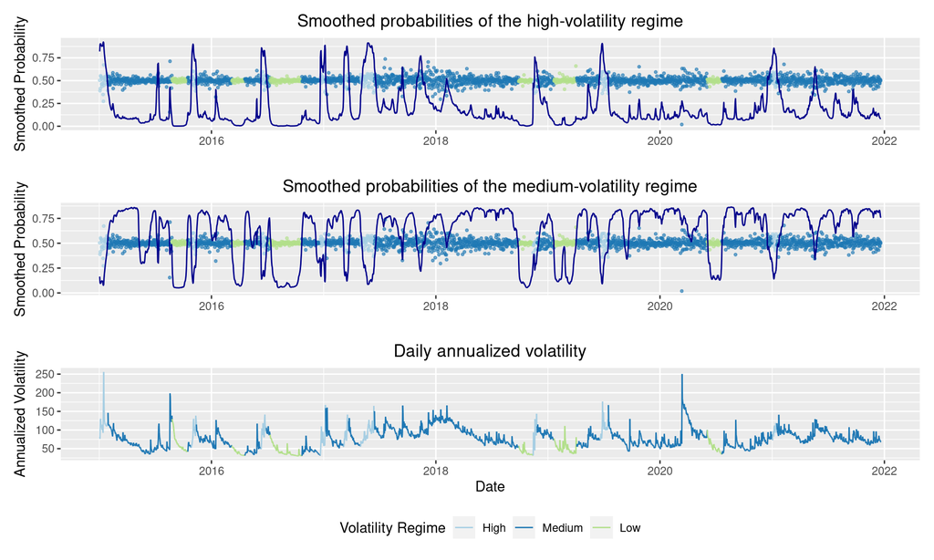

```r
mcmc_regime_mapping <- data.frame(
    row.names = c(1, 2, 3),
    val = c("Low", "Medium", "High")
)

mcmc_ind <- 3
mcmc_state <- State(object = mcmc_chosen_models[[mcmc_ind]])
bf_data <- bf_data %>%
    mutate(
        mcmc_smooth_prob = apply(mcmc_state$SmoothProb, c(1, 3), mean)[
            1:nrow(bf_data), 3
        ],
        mcmc_smooth_prob_med = apply(mcmc_state$SmoothProb, c(1, 3), mean)[
            1:nrow(bf_data), 2
        ],
        mcmc_volatility = sqrt(365) * Volatility(mcmc_chosen_models[[mcmc_ind]]),
        mcmc_viterbi = as_factor(
            sapply(
                apply(mcmc_state$Viterbi, 1, getmode),
                function(x) mcmc_regime_mapping[x, ]
            )
        )
    )

mcmc_smoothed_prob_plot = ggplot(data = bf_data, aes(x = Date)) +
    geom_point(
        aes(y = log_return / 100 + 0.5, color = mcmc_viterbi),
        size = 0.7,
        alpha = 0.6
    ) +
    geom_line(aes(y = mcmc_smooth_prob), color="darkblue") +
    xlab("") +
    ylab("Smoothed Probability") +
    theme(
        legend.position = "none",
        plot.title = element_text(hjust = 0.5)
    ) +
    scale_color_brewer(palette = "Paired") +
    ggtitle("Smoothed probabilities of the high-volatility regime")

mcmc_smoothed_prob_med_plot = ggplot(data = bf_data, aes(x = Date)) +
    geom_point(
        aes(y = log_return / 100 + 0.5, color = mcmc_viterbi),
        size = 0.7,
        alpha = 0.6
    ) +
    geom_line(aes(y = mcmc_smooth_prob_med), color="darkblue") +
    xlab("") +
    ylab("Smoothed Probability") +
    theme(
        legend.position = "none",
        plot.title = element_text(hjust = 0.5)
    ) +
    scale_color_brewer(palette = "Paired") +
    ggtitle("Smoothed probabilities of the medium-volatility regime")

mcmc_volatility_plot = ggplot(data = bf_data, aes(x = Date)) +
    geom_line(aes(y = mcmc_volatility, color = mcmc_viterbi, group = 1)) +
    xlab("Date") +
    ylab("Annualized Volatility") +
    labs(color="Volatility Regime") +
    theme(
        legend.position = "bottom",
        plot.title = element_text(hjust = 0.5)
    ) +
    scale_color_brewer(palette = "Paired") +
    ggtitle("Daily annualized volatility")

mcmc_prob_vol_plot <- mcmc_smoothed_prob_plot / mcmc_smoothed_prob_med_plot / mcmc_volatility_plot

ggsave(
    "./latex/empirical_results/mcmc_prob_vol_plot.png",
    mcmc_prob_vol_plot,
    width = 8,
    height = 9,
    dpi = "print"
)

mcmc_prob_vol_plot
```

## Out-of-sample analysis

### MLE

Calculate 1-step-ahead VaR for out-of-sample data.

```r
# define VaR prediction calculation
var_one_step_ahead <- function(
    data,
    date,
    new_data,
    model_spec,
    spec_name = NULL,
    fit_length = 1500,
    num_pred_days = 5,
    max_fit_attempts = 3,
    optim_fn = FitML
) {
    alphas <- c(0.005, 0.01, 0.05, 0.1)
    # get the right data and metadata
    fit_log_returns <- data %>%
        filter(Date < date) %>%
        select(log_return) %>%
        slice_tail(n = fit_length)
    oos_data <- data %>%
        filter(Date >= date) %>%
        slice_head(n = num_pred_days)
    oos_log_returns <- oos_data$log_return
    oos_dates <- oos_data$Date
    # fit model with retry
    attempt <- 1
    fitted_model = NULL
    while( attempt <= max_fit_attempts ) {
        attempt <- attempt + 1
        try(
            fitted_model <- optim_fn(
                spec=model_spec,
                data=as.matrix(fit_log_returns)
            )
        )
    }
    if (is.null(fitted_model)) {
        err_mess = sprintf(
            "Optim for date %s failed after %i attempts",
            date, max_fit_attempts
        )
        return(date)
    }
    # predict 1-step-ahead VaR for the next days
    # without updating the model
    oos_sink = c()
    VaR_results = list()
    for (i in 1:(num_pred_days)) {
        predicted_VaR <- Risk(
            fitted_model,
            newdata = oos_sink,
            alpha = alphas,
            do.es = FALSE
        )
        predicted_VaR <- as_tibble(predicted_VaR$VaR)
        predicted_VaR$date <- oos_dates[i]
        predicted_VaR$name <- spec_name
        VaR_results[[i]] <- predicted_VaR
        # add the data point to sink for next
        # 1-step-ahead prediction
        oos_sink = append(oos_sink, oos_log_returns[i])
    }
    VaR_results = bind_rows(VaR_results)
    VaR_results$order = seq(1, num_pred_days)
    return(VaR_results)
}
# define dates to run
n_cores <- 8L
oos_dates <- bf_data %>%
    filter(Date >= "2021-01-01") %>%
    # filter(Date >= "2020-01-01") %>%
    # filter(Date >= "2019-05-01") %>%
    select(Date)
fit_data_length = nrow(bf_data) - nrow(oos_dates)
num_pred_days = 5
dates_to_run <- oos_dates$Date[seq(
    1, nrow(oos_dates), num_pred_days)]

# create model specs
oos_spec_options <- list(
    model=c("sGARCH"),
    distribution=c("sstd")
)
oos_specs <- lapply(
    c(1, 2, 3),
    function(k) {
        CreateSpec(
            variance.spec = oos_spec_options,
            distribution.spec = oos_spec_options,
            switch.spec = list(
                do.mix = FALSE,
                K = k
            )
        )
    }
)

# single-regime GARCH
oos_VaR_results_1 <- mclapply(
    dates_to_run,
    var_one_step_ahead,
    data = bf_data,
    model_spec = oos_specs[[1]],
    fit_length = fit_data_length,
    num_pred_days = num_pred_days,
    spec_name = "VaR - MSGARCH(1)",
    mc.cores = getOption("mc.cores", n_cores)
)

oos_VaR_results_2 <- mclapply(
    dates_to_run,
    var_one_step_ahead,
    data = bf_data,
    model_spec = oos_specs[[2]],
    fit_length = fit_data_length,
    num_pred_days = num_pred_days,
    spec_name = "VaR - MSGARCH(2)",
    mc.cores = getOption("mc.cores", n_cores)
)

oos_VaR_results_3 <- mclapply(
    dates_to_run,
    var_one_step_ahead,
    data = bf_data,
    model_spec = oos_specs[[3]],
    fit_length = fit_data_length,
    num_pred_days = num_pred_days,
    spec_name = "VaR - MSGARCH(3)",
    mc.cores = getOption("mc.cores", n_cores)
)
oos_VaR_results_1 <- bind_rows(oos_VaR_results_1)
oos_VaR_results_2 <- bind_rows(oos_VaR_results_2)
oos_VaR_results_3 <- bind_rows(oos_VaR_results_3)
oos_VaR_results <- bind_rows(list(
    oos_VaR_results_1,
    oos_VaR_results_2,
    oos_VaR_results_3
))
```

For testing purpose. Sometimes `FitML` throws error due to non-finite objective function value. Here we try to find the date where that happens.

```r
data <- bf_data
date <- "2021-01-15"
# get the right data and metadata
fit_log_returns <- data %>%
    filter(Date < date) %>%
    select(log_return) %>%
    slice_tail(n = fit_data_length)
oos_data <- data %>%
    filter(Date >= date) %>%
    slice_head(n = num_pred_days)
oos_log_returns <- oos_data$log_return
oos_dates <- oos_data$Date

fitted_model <- FitML(
    spec = oos_specs[[1]],
    data = fit_log_returns$log_return
)
```

Then we visualize outputs before doing tests.

```r
oos_VaR_results <- bf_data %>%
    select(Date, log_return) %>%
    merge(
        x = .,
        y = oos_VaR_results,
        by.x = "Date",
        by.y = "date"
    )
oos_VaR_results <- as_tibble(oos_VaR_results)
oos_VaR_results
```

```
## # A tibble: 1,062 × 8
##    Date       log_return `0.005` `0.01` `0.05` `0.1` name             order
##    <date>          <dbl>   <dbl>  <dbl>  <dbl> <dbl> <chr>            <int>
##  1 2021-01-01       1.42   -13.7  -10.7  -5.58 -3.91 VaR - MSGARCH(1)     1
##  2 2021-01-01       1.42   -15.5  -13.0  -7.74 -5.50 VaR - MSGARCH(3)     1
##  3 2021-01-01       1.42   -14.4  -11.9  -6.86 -4.86 VaR - MSGARCH(2)     1
##  4 2021-01-02       9.23   -13.0  -10.2  -5.35 -3.75 VaR - MSGARCH(1)     2
##  5 2021-01-02       9.23   -15.1  -12.6  -7.34 -5.19 VaR - MSGARCH(3)     2
##  6 2021-01-02       9.23   -14.0  -11.5  -6.54 -4.63 VaR - MSGARCH(2)     2
##  7 2021-01-03       2.41   -16.7  -13.1  -6.86 -4.78 VaR - MSGARCH(1)     3
##  8 2021-01-03       2.41   -16.6  -13.7  -7.98 -5.74 VaR - MSGARCH(2)     3
##  9 2021-01-03       2.41   -17.7  -14.9  -8.94 -6.38 VaR - MSGARCH(3)     3
## 10 2021-01-04      -2.93   -16.0  -12.6  -6.62 -4.62 VaR - MSGARCH(1)     4
## # … with 1,052 more rows
```

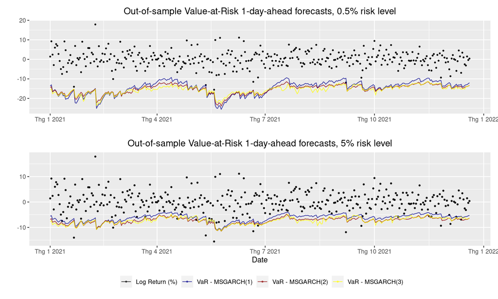

```r
VaR_0005_plot <- ggplot(data = oos_VaR_results, aes(x = Date)) +
    geom_point(
        aes(y = log_return, color = "Log Return (%)"),
        alpha = 0.5,
        size = 0.6
    ) +
    geom_line(
        aes(y = `0.005`, color = name),
        alpha = 0.7
    ) +
    scale_color_manual("", values = c(
        "Log Return (%)" = "black",
        "VaR - MSGARCH(1)" = "darkblue",
        "VaR - MSGARCH(2)" = "darkred",
        "VaR - MSGARCH(3)" = "yellow"
    )) +
    xlab("") +
    ylab("") +
    theme(
        legend.position = "none",
        plot.title = element_text(hjust = 0.5)
    ) +
    ggtitle(
        "Out-of-sample Value-at-Risk 1-day-ahead forecasts, 0.5% risk level")

VaR_005_plot <- ggplot(data = oos_VaR_results, aes(x = Date)) +
    geom_point(
        aes(y = log_return, color = "Log Return (%)"),
        alpha = 0.5,
        size = 0.7
    ) +
    geom_line(
        aes(y = `0.05`, color = name),
        alpha = 0.7
    ) +
    ylab("") +
    scale_color_manual("", values = c(
        "Log Return (%)" = "black",
        "VaR - MSGARCH(1)" = "darkblue",
        "VaR - MSGARCH(2)" = "darkred",
        "VaR - MSGARCH(3)" = "yellow"
    )) +
    theme(
        legend.position = "bottom",
        plot.title = element_text(hjust = 0.5)
    ) +
    ggtitle(
        "Out-of-sample Value-at-Risk 1-day-ahead forecasts, 5% risk level")

oos_VaR_plot <- VaR_0005_plot / VaR_005_plot
ggsave(
    "./latex/empirical_results/oos_VaR.png",
    oos_VaR_plot,
    width = 8,
    height = 5,
    dpi = "print"
)
oos_VaR_plot
```

Now, we do some LR tests

```r
LR_test_single_alpha <- function(df, alp) {
    single_alpha_df <- df %>%
        filter(alpha == alp) %>%
        arrange(Date)
    # do backtest
    raw_test_results = BacktestVaR(
        data = single_alpha_df$log_return,
        VaR = single_alpha_df$VaR,
        alpha = alp
    )
    lr_results <- bind_rows(raw_test_results[c("LRuc", "LRcc")])
    colnames(lr_results) <- c("test_statistics", "p_value")
    lr_results$test_name <- c("LRuc", "LRcc")
    lr_results$alpha <- alp
    return(lr_results)
}

do_LR_test <- function(
    oos_VaR_data,
    model_name,
    alphas = c(0.005, 0.01, 0.05, 0.1)
) {
    # prepare data
    LR_test_data <- oos_VaR_data %>%
        filter(name == model_name) %>%
        pivot_longer(
            cols = as.character(alphas),
            names_to = "alpha",
            values_to = "VaR"
        ) %>%
        mutate(alpha = as.numeric(alpha))
    # do backtest
    results = lapply(
        alphas,
        LR_test_single_alpha,
        df = LR_test_data
    )
    results_df <- bind_rows(results)
    results_df$model_name <- model_name
    results_df
}


lr_test_results <- lapply(
    unique(oos_VaR_results$name),
    do_LR_test,
    oos_VaR_data = oos_VaR_results,
    alphas = c(0.005, 0.01, 0.05, 0.1)
)
lr_test_results <- bind_rows(lr_test_results)
lr_test_results_stats <- lr_test_results %>%
    pivot_wider(
        id_cols = c(model_name, test_name),
        names_from = c(alpha),
        values_from = c(test_statistics)
    )
lr_test_results_p_vals <- lr_test_results %>%
    pivot_wider(
        id_cols = c(model_name, test_name),
        names_from = c(alpha),
        values_from = c(p_value)
    )
lr_test_results_all <- lr_test_results %>%
    pivot_wider(
        id_cols = c(model_name, test_name),
        names_from = c(alpha),
        values_from = c(test_statistics, p_value)
    ) %>%
    arrange(model_name)

knitr::kable(lr_test_results_all, "simple")
```

| model_name | test_name | test_statistics_0.005 | test_statistics_0.01 | test_statistics_0.05 | test_statistics_0.1 | p_value_0.005 | p_value_0.01 | p_value_0.05 | p_value_0.1 |
| --- | --- | --- | --- | --- | --- | --- | --- | --- | --- |
| VaR - MSGARCH(1) | LRuc | 0.0288208 | 1.4289010 | 0.3024713 | 5.2496121 | 0.8651936 | 0.2319439 | 0.5823372 | 0.0219517 |
| VaR - MSGARCH(1) | LRcc | 0.0516129 | 1.6364042 | 2.7063202 | 5.2573549 | 0.9745237 | 0.4412242 | 0.2584223 | 0.0721739 |
| VaR - MSGARCH(2) | LRuc | 3.5488796 | 0.0579451 | 0.8743545 | 0.1845528 | 0.0595857 | 0.8097738 | 0.3497526 | 0.6674895 |
| VaR - MSGARCH(2) | LRcc | 3.5488796 | 0.1496377 | 2.0310256 | 0.1874231 | 0.1695784 | 0.9279116 | 0.3622166 | 0.9105454 |
| VaR - MSGARCH(3) | LRuc | 3.5488796 | 0.0579451 | 0.0295120 | 0.1845528 | 0.0595857 | 0.8097738 | 0.8636022 | 0.6674895 |
| VaR - MSGARCH(3) | LRcc | 3.5488796 | 0.1496377 | 1.7504848 | 0.1874231 | 0.1695784 | 0.9279116 | 0.4167610 | 0.9105454 |

```r
print(lr_test_results_all)
```

```
## # A tibble: 6 × 10
##   model_name       test_name test_statistics_… test_statistics… test_statistics…
##   <chr>            <chr>                 <dbl>            <dbl>            <dbl>
## 1 VaR - MSGARCH(1) LRuc                 0.0288           1.43             0.302
## 2 VaR - MSGARCH(1) LRcc                 0.0516           1.64             2.71
## 3 VaR - MSGARCH(2) LRuc                 3.55             0.0579           0.874
## 4 VaR - MSGARCH(2) LRcc                 3.55             0.150            2.03
## 5 VaR - MSGARCH(3) LRuc                 3.55             0.0579           0.0295
## 6 VaR - MSGARCH(3) LRcc                 3.55             0.150            1.75
## # … with 5 more variables: test_statistics_0.1 <dbl>, p_value_0.005 <dbl>,
## #   p_value_0.01 <dbl>, p_value_0.05 <dbl>, p_value_0.1 <dbl>
```

```r
# print(lr_test_results_stats)
# print(lr_test_results_p_vals)
```

Table of hits

```r
alphas = c(0.005, 0.01, 0.05, 0.1)
VaR_hit_df <- oos_VaR_results %>%
    pivot_longer(
        cols = as.character(alphas),
        names_to = "alpha",
        values_to = "VaR"
    ) %>%
    mutate(
        alpha = as.numeric(alpha),
        hit = log_return < VaR
    ) %>%
    pivot_wider(
        id_cols = c(name),
        names_from = c(alpha),
        values_from = c(hit),
        values_fn = sum
    ) %>%
    add_row(
        name = "Expected # of hits",
        `0.005` = 0.005 * nrow(oos_VaR_results),
        `0.01` = 0.01 * nrow(oos_VaR_results),
        `0.05` = 0.05 * nrow(oos_VaR_results),
        `0.1` = 0.1 * nrow(oos_VaR_results),
    ) %>%
    arrange(name)

knitr::kable(VaR_hit_df, "simple")
```

| name | 0.005 | 0.01 | 0.05 | 0.1 |
| --- | --- | --- | --- | --- |
| Expected # of hits | 5.31 | 10.62 | 53.1 | 106.2 |
| VaR - MSGARCH(1) | 2.00 | 6.00 | 20.0 | 49.0 |
| VaR - MSGARCH(2) | 0.00 | 4.00 | 14.0 | 33.0 |
| VaR - MSGARCH(3) | 0.00 | 4.00 | 17.0 | 33.0 |

### Bayesian

```r
# define dates to run
n_cores <- 8L
oos_dates <- bf_data %>%
    filter(Date >= "2021-01-01") %>%
    # filter(Date >= "2020-01-01") %>%
    # filter(Date >= "2019-05-01") %>%
    select(Date)
fit_data_length = nrow(bf_data) - nrow(oos_dates)
num_pred_days = 5
dates_to_run <- oos_dates$Date[seq(
    1, nrow(oos_dates), num_pred_days)]

# create model specs
mcmc_oos_spec_options <- list(
    model=c("gjrGARCH"),
    distribution=c("sstd")
)
mcmc_oos_specs <- lapply(
    c(1, 2, 3),
    function(k) {
        CreateSpec(
            variance.spec = mcmc_oos_spec_options,
            distribution.spec = mcmc_oos_spec_options,
            switch.spec = list(
                do.mix = FALSE,
                K = k
            )
        )
    }
)

# single-regime GARCH
mcmc_oos_VaR_results_1 <- mclapply(
    dates_to_run,
    var_one_step_ahead,
    data = bf_data,
    model_spec = mcmc_oos_specs[[1]],
    fit_length = fit_data_length,
    num_pred_days = num_pred_days,
    spec_name = "VaR - MCMC - MSGARCH(1)",
    optim_fn = FitMCMC,
    mc.cores = getOption("mc.cores", n_cores)
)

mcmc_oos_VaR_results_2 <- mclapply(
    dates_to_run,
    var_one_step_ahead,
    data = bf_data,
    model_spec = mcmc_oos_specs[[2]],
    fit_length = fit_data_length,
    num_pred_days = num_pred_days,
    spec_name = "VaR - MCMC - MSGARCH(2)",
    optim_fn = FitMCMC,
    mc.cores = getOption("mc.cores", n_cores)
)

mcmc_oos_VaR_results_3 <- mclapply(
    dates_to_run,
    var_one_step_ahead,
    data = bf_data,
    model_spec = mcmc_oos_specs[[3]],
    fit_length = fit_data_length,
    num_pred_days = num_pred_days,
    spec_name = "VaR - MCMC - MSGARCH(3)",
    optim_fn = FitMCMC,
    mc.cores = getOption("mc.cores", n_cores)
)
mcmc_oos_VaR_results_1 <- bind_rows(mcmc_oos_VaR_results_1)
mcmc_oos_VaR_results_2 <- bind_rows(mcmc_oos_VaR_results_2)
mcmc_oos_VaR_results_3 <- bind_rows(mcmc_oos_VaR_results_3)
mcmc_oos_VaR_results <- bind_rows(list(
    mcmc_oos_VaR_results_1,
    mcmc_oos_VaR_results_2,
    mcmc_oos_VaR_results_3
))
```

Then we visualize outputs before doing tests.

```r
mcmc_oos_VaR_results <- bf_data %>%
    select(Date, log_return) %>%
    merge(
        x = .,
        y = mcmc_oos_VaR_results,
        by.x = "Date",
        by.y = "date"
    )
mcmc_oos_VaR_results <- as_tibble(mcmc_oos_VaR_results)
mcmc_oos_VaR_results
```

```
## # A tibble: 1,062 × 8
##    Date       log_return `0.005` `0.01` `0.05` `0.1` name                  order
##    <date>          <dbl>   <dbl>  <dbl>  <dbl> <dbl> <chr>                 <int>
##  1 2021-01-01       1.42   -13.7  -10.7  -5.58 -3.91 VaR - MCMC - MSGARCH…     1
##  2 2021-01-01       1.42   -15.0  -12.9  -7.74 -5.50 VaR - MCMC - MSGARCH…     1
##  3 2021-01-01       1.42   -16.1  -13.2  -7.34 -5.02 VaR - MCMC - MSGARCH…     1
##  4 2021-01-02       9.23   -13.0  -10.2  -5.35 -3.67 VaR - MCMC - MSGARCH…     2
##  5 2021-01-02       9.23   -14.6  -12.4  -7.26 -5.03 VaR - MCMC - MSGARCH…     2
##  6 2021-01-02       9.23   -15.4  -12.5  -6.86 -4.63 VaR - MCMC - MSGARCH…     2
##  7 2021-01-03       2.41   -17.0  -13.3  -7.02 -4.86 VaR - MCMC - MSGARCH…     3
##  8 2021-01-03       2.41   -18.4  -15.2  -8.70 -6.06 VaR - MCMC - MSGARCH…     3
##  9 2021-01-03       2.41   -16.9  -14.5  -9.10 -6.70 VaR - MCMC - MSGARCH…     3
## 10 2021-01-04      -2.93   -16.2  -12.8  -6.70 -4.62 VaR - MCMC - MSGARCH…     4
## # … with 1,052 more rows
```

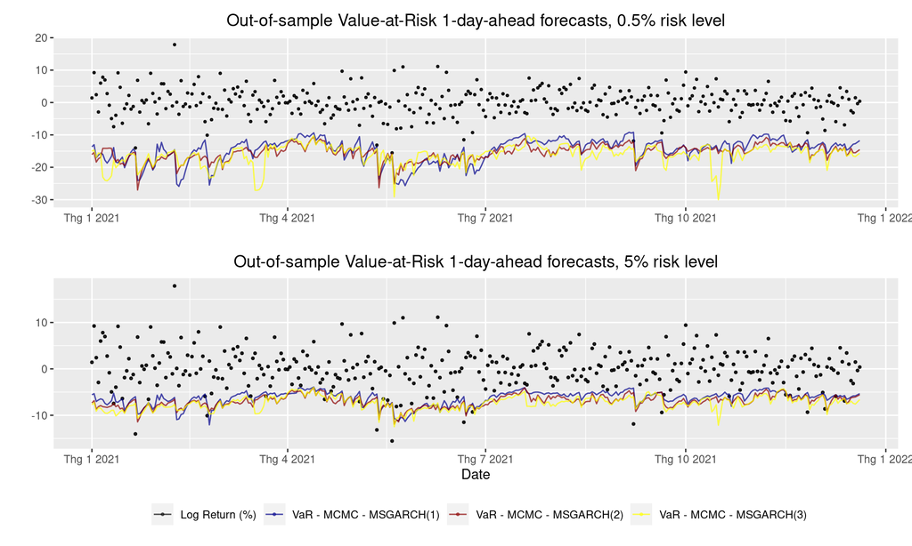

```r
mcmc_VaR_0005_plot <- ggplot(data = mcmc_oos_VaR_results, aes(x = Date)) +
    geom_point(
        aes(y = log_return, color = "Log Return (%)"),
        alpha = 0.5,
        size = 0.6
    ) +
    geom_line(
        aes(y = `0.005`, color = name),
        alpha = 0.7
    ) +
    scale_color_manual("", values = c(
        "Log Return (%)" = "black",
        "VaR - MCMC - MSGARCH(1)" = "darkblue",
        "VaR - MCMC - MSGARCH(2)" = "darkred",
        "VaR - MCMC - MSGARCH(3)" = "yellow"
    )) +
    xlab("") +
    ylab("") +
    theme(
        legend.position = "none",
        plot.title = element_text(hjust = 0.5)
    ) +
    ggtitle(
        "Out-of-sample Value-at-Risk 1-day-ahead forecasts, 0.5% risk level")

mcmc_VaR_005_plot <- ggplot(data = mcmc_oos_VaR_results, aes(x = Date)) +
    geom_point(
        aes(y = log_return, color = "Log Return (%)"),
        alpha = 0.5,
        size = 0.7
    ) +
    geom_line(
        aes(y = `0.05`, color = name),
        alpha = 0.7
    ) +
    ylab("") +
    scale_color_manual("", values = c(
        "Log Return (%)" = "black",
        "VaR - MCMC - MSGARCH(1)" = "darkblue",
        "VaR - MCMC - MSGARCH(2)" = "darkred",
        "VaR - MCMC - MSGARCH(3)" = "yellow"
    )) +
    theme(
        legend.position = "bottom",
        plot.title = element_text(hjust = 0.5)
    ) +
    ggtitle(
        "Out-of-sample Value-at-Risk 1-day-ahead forecasts, 5% risk level")

mcmc_oos_VaR_plot <- mcmc_VaR_0005_plot / mcmc_VaR_005_plot
ggsave(
    "./latex/empirical_results/mcmc_oos_VaR.png",
    mcmc_oos_VaR_plot,
    width = 8,
    height = 5,
    dpi = "print"
)
mcmc_oos_VaR_plot
```

Now, we do some LR tests

```r
mcmc_lr_test_results <- lapply(
    unique(mcmc_oos_VaR_results$name),
    do_LR_test,
    oos_VaR_data = mcmc_oos_VaR_results,
    alphas = c(0.005, 0.01, 0.05, 0.1)
)
mcmc_lr_test_results <- bind_rows(mcmc_lr_test_results)
mcmc_lr_test_results_stats <- mcmc_lr_test_results %>%
    pivot_wider(
        id_cols = c(model_name, test_name),
        names_from = c(alpha),
        values_from = c(test_statistics)
    )
mcmc_lr_test_results_p_vals <- mcmc_lr_test_results %>%
    pivot_wider(
        id_cols = c(model_name, test_name),
        names_from = c(alpha),
        values_from = c(p_value)
    )
mcmc_lr_test_results_all <- mcmc_lr_test_results %>%
    pivot_wider(
        id_cols = c(model_name, test_name),
        names_from = c(alpha),
        values_from = c(test_statistics, p_value)
    ) %>%
    arrange(model_name)

knitr::kable(mcmc_lr_test_results_all, "simple")
```

| model_name | test_name | test_statistics_0.005 | test_statistics_0.01 | test_statistics_0.05 | test_statistics_0.1 | p_value_0.005 | p_value_0.01 | p_value_0.05 | p_value_0.1 |
| --- | --- | --- | --- | --- | --- | --- | --- | --- | --- |
| VaR - MCMC - MSGARCH(1) | LRuc | 0.3997230 | 2.6592406 | 0.3024713 | 3.2541665 | 0.5272324 | 0.1029499 | 0.5823372 | 0.0712421 |
| VaR - MCMC - MSGARCH(1) | LRcc | 0.4054048 | 2.9424969 | 0.3206986 | 4.2172222 | 0.8165212 | 0.2296386 | 0.8518462 | 0.1214065 |
| VaR - MCMC - MSGARCH(2) | LRuc | 3.5488796 | 0.0579451 | 0.0053240 | 2.1723056 | 0.0595857 | 0.8097738 | 0.9418336 | 0.1405154 |
| VaR - MCMC - MSGARCH(2) | LRcc | 3.5488796 | 0.1496377 | 1.9405841 | 2.7373498 | 0.1695784 | 0.9279116 | 0.3789723 | 0.2544439 |
| VaR - MCMC - MSGARCH(3) | LRuc | 3.5488796 | 0.0579451 | 0.1773497 | 0.0050389 | 0.0595857 | 0.8097738 | 0.6736608 | 0.9434096 |
| VaR - MCMC - MSGARCH(3) | LRcc | 3.5488796 | 0.1496377 | 1.6972088 | 0.0865847 | 0.1695784 | 0.9279116 | 0.4280118 | 0.9576314 |

```r
print(mcmc_lr_test_results_all)
```

```
## # A tibble: 6 × 10
##   model_name     test_name test_statistics_… test_statistics_… test_statistics_…
##   <chr>          <chr>                 <dbl>             <dbl>             <dbl>
## 1 VaR - MCMC - … LRuc                  0.400            2.66             0.302
## 2 VaR - MCMC - … LRcc                  0.405            2.94             0.321
## 3 VaR - MCMC - … LRuc                  3.55             0.0579           0.00532
## 4 VaR - MCMC - … LRcc                  3.55             0.150            1.94
## 5 VaR - MCMC - … LRuc                  3.55             0.0579           0.177
## 6 VaR - MCMC - … LRcc                  3.55             0.150            1.70
## # … with 5 more variables: test_statistics_0.1 <dbl>, p_value_0.005 <dbl>,
## #   p_value_0.01 <dbl>, p_value_0.05 <dbl>, p_value_0.1 <dbl>
```

```r
# print(lr_test_results_stats)
# print(lr_test_results_p_vals)
```

Table of hits

```r
alphas = c(0.005, 0.01, 0.05, 0.1)
mcmc_VaR_hit_df <- mcmc_oos_VaR_results %>%
    pivot_longer(
        cols = as.character(alphas),
        names_to = "alpha",
        values_to = "VaR"
    ) %>%
    mutate(
        alpha = as.numeric(alpha),
        hit = log_return < VaR
    ) %>%
    pivot_wider(
        id_cols = c(name),
        names_from = c(alpha),
        values_from = c(hit),
        values_fn = sum
    ) %>%
    add_row(
        name = "Expected # of hits",
        `0.005` = 0.005 * nrow(mcmc_oos_VaR_results),
        `0.01` = 0.01 * nrow(mcmc_oos_VaR_results),
        `0.05` = 0.05 * nrow(mcmc_oos_VaR_results),
        `0.1` = 0.1 * nrow(mcmc_oos_VaR_results),
    ) %>%
    arrange(name)

knitr::kable(mcmc_VaR_hit_df, "simple")
```

| name | 0.005 | 0.01 | 0.05 | 0.1 |
| --- | --- | --- | --- | --- |
| Expected # of hits | 5.31 | 10.62 | 53.1 | 106.2 |
| VaR - MCMC - MSGARCH(1) | 1.00 | 7.00 | 20.0 | 46.0 |
| VaR - MCMC - MSGARCH(2) | 0.00 | 4.00 | 18.0 | 44.0 |
| VaR - MCMC - MSGARCH(3) | 0.00 | 4.00 | 16.0 | 35.0 |